# Simulated Probabilistic Distributions

Scott Coffin

2/24/2021

#Setup

```r
# Bimodal universal shape distribution for environmental microplastic from Kooi and Koelmans (2019)
library(truncnorm)
library(tidyverse)
library(MonteCarlo)# Monte Carlo Simulation
library(gridExtra)
library(msm) ## rtnorm - get upper and lower limit of shape distribution
library(GeneralizedHyperbolic) ## normal-inverse Gaussian
```

# 1 Resources:

https://pubs.acs.org/doi/suppl/10.1021/acs.est.0c02982/suppl_file/es0c02982_si_001.pdf https://pubs.acs.org/doi/suppl/10.1021/acs.estlett.9b00379/suppl_file/ez9b00379_si_001.pdf https://pubs.acs.org/doi/10.1021/acs.estlett.9b00379

# 2 Generate Particles

Shape is defined as: Simplifed equation for corey shape factor:

$CSF = H/sqrt(LW)$

Equation for abundance of particles based on density (two distributions). (Note that this is *equation 4* in Kooi and Koelmans (2019).)

$y = f1(\frac{1}{sqrt(2pi()\sigma_1^2})e^{-(x-\mu_1)^2/2\sigma_1^2} + f2(\frac{1}{sqrt(2pi()\sigma_2^2})e^{-(x-\mu_2)^2/2\sigma_2^2}$

For polymer abundance, for the K&K2019 paper I used the fixed values from Burns & Boxall review, and went straight for density. Given these fixed relative abundances, you could calculate polymer type randomly for N particles via:

pols <- c(“PE”, “PP”, “PS”) rel.ab <- c(0.5, 0.3, 0.2) n = 1000 sample(pols, size = n, prob = rel.ab, replace = TRUE)

Particle volume is determined according to shape as follows:

$V = \frac{\pi}{6}L^3CSF^2$

Where CSF = corey shape factor and L = length.

Particle mass is estimated as follows:

$m = pV*\frac{1}{1e12}*1000$

Where *m* is the mass (mg), *p* is density (g/cm^3), *V* is volume (um^3) - which is calculated by the cube of the length (um) of each particle, and additional conversion factors for mg to g (x1000) and cm^3 to um^3 (1e-12).

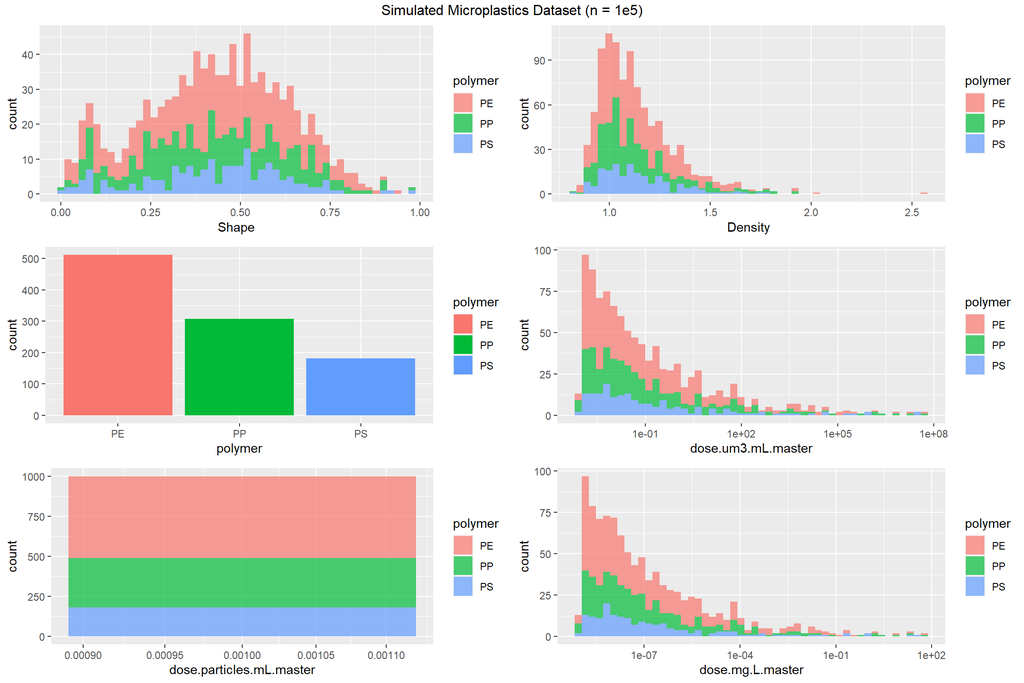

```r
##++++++++++++++++++++++++++++++++++++++++
## Quick check results
##++++++++++++++++++++++++++++++++++++++++
#p1 <- ggplot(Data_final, aes(x = Size, fill = polymer)) + geom_histogram(bins = 50, alpha = 0.7) + scale_x_log10()
p2 <- ggplot(Data_final, aes(x = Shape, fill = polymer)) + geom_histogram(bins = 50, alpha = 0.7)
p3 <- ggplot(Data_final, aes(x = Density, fill = polymer)) + geom_histogram(bins = 50, alpha = 0.7)
p4 <- ggplot(Data_final, aes(x = polymer, fill = polymer)) + geom_histogram(stat = "count")
#p5 <- ggplot(Data_final, aes(x = mass.mg, fill = polymer)) + geom_histogram(bins = 50, alpha = 0.7 )+ scale_x_log10()
#p6 <- ggplot(Data_final, aes(x = um3, fill = polymer)) + geom_histogram(bins = 50, alpha = 0.7)+ scale_x_log10()
p7 <- ggplot(Data_final, aes(x = dose.um3.mL.master, fill = polymer)) + geom_histogram(bins = 50, alpha = 0.7)+ scale_x_log10()
p8 <- ggplot(Data_final, aes(x = dose.particles.mL.master, fill = polymer)) + geom_histogram(bins = 50, alpha = 0.7)+ scale_x_log10()
p9 <- ggplot(Data_final, aes(x = dose.mg.L.master, fill = polymer)) + geom_histogram(bins = 50, alpha = 0.7)+ scale_x_log10()
grid.arrange(#p1,
             p2,
             p3,
             p4,
             #p5,
             #p6,
             p7,
             p8,
             p9,
             top = "Simulated Microplastics Dataset (n = 1e5)")
```

# 3 Predict Toxicities

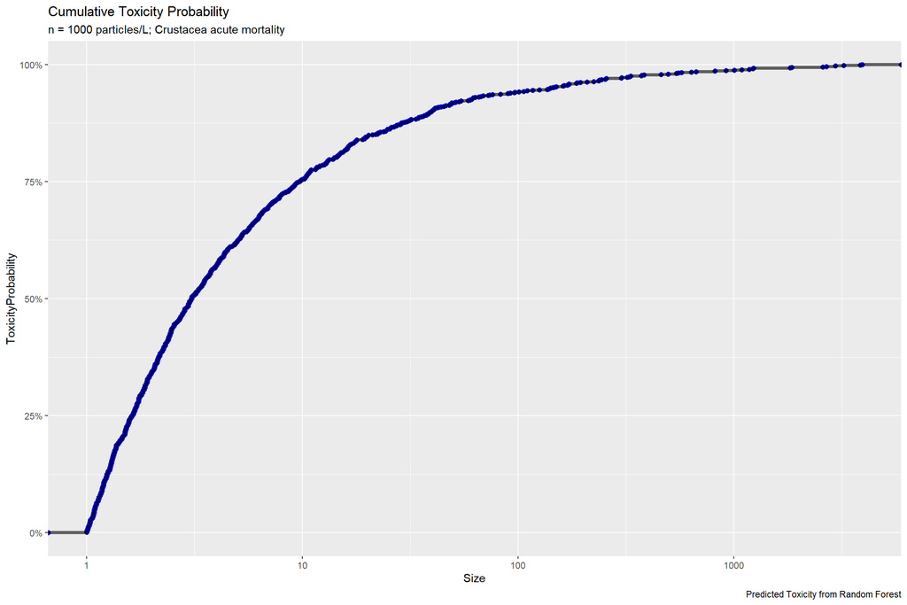

```r
#pull in model from DALEX
final_model <- readRDS("final_rf_model.rds")

### parameters ###
df_1 <- Data_final %>%
  mutate(treatments = 1) %>%
  mutate(organism.group = "Crustacea") %>%
  mutate(exposure.duration.d = 28) %>%
  mutate(lvl1_f = "Fitness") %>%
  mutate(life.stage= "Juvenile") %>%
  mutate(bio.org = "organism.group") %>%
  mutate(effect.metric = "NOEC") %>%
  mutate(environment = "Marine") %>%
  mutate(exposure.route = "water") %>%
  mutate(lvl2_f = "Mortality")

df_1_pred <- predict(final_model, newdata = df_1, type = "prob")
df_1_pred_final <- cbind(df_1, df_1_pred) %>%
  rename("ToxicityProbability" = `1`)

df_1_pred_final %>% ggplot(aes(x = Size, y = ToxicityProbability)) +
  stat_ecdf(geom = "point", size = 2, color = "blue")+
  stat_ecdf(geom = "step", linetype = 'solid', alpha = 0.6, size = 1.5) +
  scale_x_log10() +
  scale_y_continuous(labels = scales::percent)+
  labs(title = "Cumulative Toxicity Probability",
       subtitle = "n = 1000 particles/L; Crustacea acute mortality",
       caption = "Predicted Toxicity from Random Forest")
```